# first-order

```r
library(doremi)
library(ggplot2)
library(data.table)
library(futile.logger)
set.seed(1)
```

# FIRST ORDER DIFFERENTIAL EQUATIONS

The linear first order differential equation with constant coefficients model is given by the following equation:
$$\tau\frac{dy}{dt} + (y-y_{eq}) = ku(t)$$
or
$$\frac{dy}{dt} + \gamma (y-y_{eq}) = \gamma ku(t)$$
with the initial condition:
$$y(t=0)=y_{0}$$
Where:

- $y(t)$ is the signal to be analyzed
- $\dot{y}(t)$ is its first derivative
- $u(t)$ is the excitation term perturbing the dynamics of $y(t)$

And regarding the coefficients:

- $\gamma$ is the decay rate.Its inverse, represents the characteristic response time of the solution of the differential equation (i.e. the time it takes to the system to go back to equilibrium)
- $k$ is the gain. It represents the proportionnality between the equilibrium value and the input maximum amplitude. It is thus relevant only for differential equations including an excitation term.
- $yeq$ is the signal equilibrium value. Value reached when the excitation term is 0 or constant.

It is common to find this equation with the excitation term set to 0, $u(t)=0$:
$$\frac{dy}{dt} + \gamma(y-y_{eq}) = 0$$

The dynamics in this case follow and exponential decay of the form $y(t)=(y_0-yeq) e^{-\gamma t} + y_{eq}$ and are provoked either by a previous excitation that is no longer present or by the displacement of the system from its equilibrium position (i.e. an initial condition different from 0)

# First order differential equation with no excitation term

## Simulating data

In this section, we present increasingly complex examples of data simulation for the first order differential equation model functions included in the package.

### Example 1a - Generating signals with no noise

In this example we will generate data for 4 individuals, with a decay time of 10s. That is, the signal follows exactly the differential equation (no dynamic noise) with no variation of the decay time, the gain and the equilibrium value across individuals (no interindividual noise). As we are considering no excitation, then, as mentioned, the system should be out of its equilibrium value to observe the dynamics of return to equilibrium.

```r
res1a <- generate.panel.1order(time = 0:99,
                               excitation = NULL,
                               y0 = 1,
                               t0 = 0,
                               exc0 = 0,
                               tau = 10,
                               k = 1,
                               yeq = 0,
                               nind = 4,
                               internoise = 0,
                               intranoise = 0)
```

As it can be seen, it can be specified to the function whether there is an excitation or not by setting the input to NULL or directly ignoring it in the input arguments. The function returns a data.table with the class ‘doremidata’. As any data.table, it can be visualized using the `str` or `head` functions or entering the variable name.

```r
res1a
```

```
#>      id time    signalraw       signal
#>   1:  1    0 1.000000e+00 1.000000e+00
#>   2:  1    1 9.048378e-01 9.048378e-01
#>   3:  1    2 8.187322e-01 8.187322e-01
#>   4:  1    3 7.408199e-01 7.408199e-01
#>   5:  1    4 6.703215e-01 6.703215e-01
#>  ---
#> 396:  4   95 7.485298e-05 7.485298e-05
#> 397:  4   96 6.773005e-05 6.773005e-05
#> 398:  4   97 6.128494e-05 6.128494e-05
#> 399:  4   98 5.545313e-05 5.545313e-05
#> 400:  4   99 5.017628e-05 5.017628e-05
```

Where:

- id is the identifier of the individual
- time is the time vector introduced as input
- signalraw is the signal without noise
- signal is the signal with noise (in this case, the values of this column are the same as those of the signalraw column and in the plot, you will see that both lines are overlapped).

Plotting the data with the plot method available in the package for doremidata objects is quite straight forward:

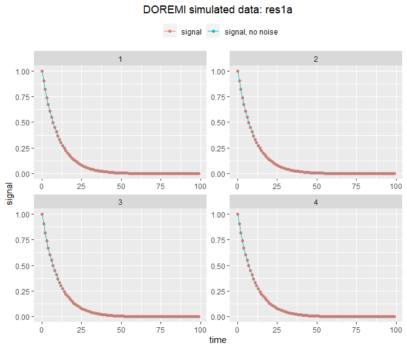

```r
plot(res1a)
```

### Example 1b - Changing initial condition, gain and equilibrium value

```r
res1b <- generate.panel.1order(time = 0:49,
                               excitation = NULL,
                               y0 = 3,
                               t0 = 0,
                               exc0 = 0,
                               tau = 5,
                               k = 0,
                               yeq = 1.5,
                               nind = 4,
                               internoise = 0,
                               intranoise = 0)
```

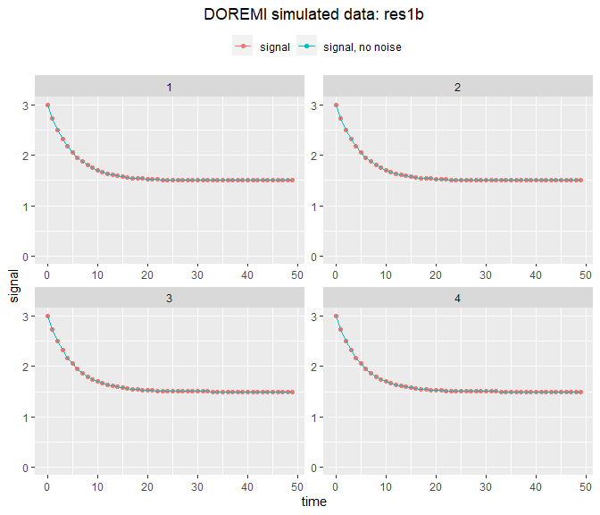

```r
plot(res1b) + scale_y_continuous(limits = c(0, 3))
```

### Example 2a - Generating signals with noise

The call to the function remains almost the same, this time we have added a signal to noise ratio (STN) of 1/0.2=5 and a 40% inter-individual noise to visualize the different trajectories for the different individuals:

```r
# Generation of signals with intra and inter-noise
res2a <- generate.panel.1order(time = 0:49,
                               excitation = NULL,
                               y0 = 1,
                               t0 = 0,
                               exc0 = 0,
                               tau = 5,
                               k = 1,
                               yeq = 0,
                               nind = 6,
                               internoise = 0.4,
                               intranoise = 5)
```

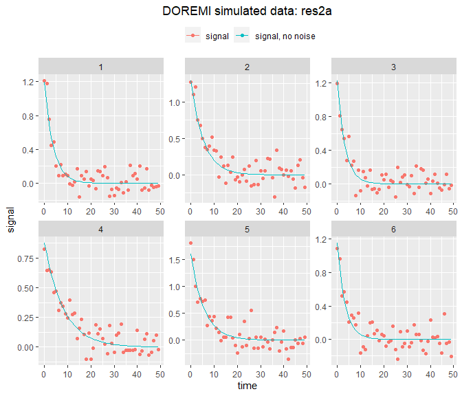

```r
plot(res2a)
```

## Analyzing data

### Example 3 - Analyzing data when the excitation is unknown, with some inter- and intraindividual noise

We will test how the analysis functions fit a decreasing exponential, as is the case when there is no excitation, when it is unknown, or when it is constant over time.

```r
#Simulating data with these hypothesis
data3 <- generate.panel.1order(time = 0:50,
                               excitation = NULL,
                               y0 = 0.5,
                               t0 = 0,
                               exc0 = 0,
                               tau = 10,
                               k = 1,
                               yeq = 0,
                               nind = 3,
                               internoise = 0.2,
                               intranoise = 100)
```

```r
#Analyzing

res3 <- analyze.1order(data = data3,
                      id = "id",
                      time = "time",
                      signal = "signal",
                      dermethod = "gold",
                      derparam = 11)
```

```
#> WARN [2020-07-10 13:06:02] No excitation signal introduced as input. Input was set to 0.
```

Note that the `input` parameter has been omitted when calling the function.

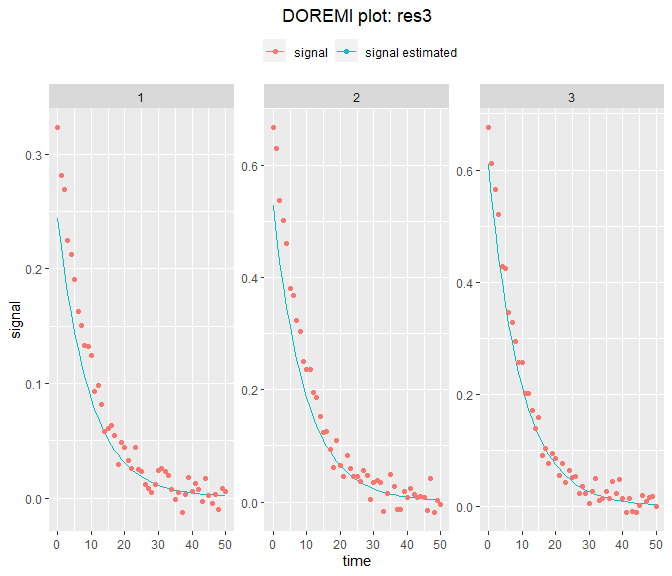

```r
#Plotting
plot(res3)
```

# First order differential equation with an excitation term

Analyzing the signals with noise generated above, we can verify that the parameters were the one introduced in the simulation function and that the estimated signals generated match the simulated ones.

# Simulating data

## Example 1a - Generating signals with no noise

In this example we will generate data for 4 individuals, with a decay time of 10s for an excitation vector formed by 3 pulses of amplitude 1 and duration 10s distributed randomly in a time period of 100s, with a minimum spacing between pulses of 20 s and with no noise. That is, the signal follows exactly the differential equation (no dynamic noise) with no variation of the decay time, the excitation coefficient and the equilibrium value across individuals (no interindividual noise).

```r
U1a <- generate.excitation(amplitude = 1,
                           nexc = 3,
                           duration = 10,
                           deltatf = 1,
                           tmax = 100,
                           minspacing = 20)

res1a <- generate.panel.1order(time = U1a$t,
                               excitation = U1a$exc,
                               y0 = 0,
                               t0 = 0,
                               exc0 = 0,
                               tau = 10,
                               k = 1,
                               yeq = 0,
                               nind = 4,
                               internoise = 0,
                               intranoise = 0)
```

## Example 1b - Changing initial condition, gain and equilibrium value

In this example we will show the flexibility of the functions to add changes on the mentioned parameters. For this, we will simplify the form of the exitation to a simple pulse:

```r
U1b <- generate.excitation(amplitude = 1,
                           nexc = 1,
                           duration = 50,
                           deltatf = 1,
                           tmax = 100,
                           minspacing = 20)

res1b <- generate.panel.1order(time = U1b$t,
                               excitation = U1b$exc,
                               y0 = 3,
                               t0 = 0,
                               exc0 = 0,
                               tau = 10,
                               k = 5,
                               yeq = 2,
                               nind = 4,
                               internoise = 0,
                               intranoise = 0)
```

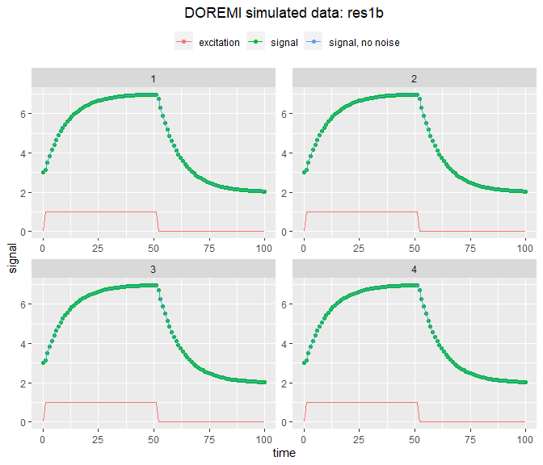

```r
plot(res1b)
```

And it can be observed how the system tends to equilibrum (2) from the initial condition (3) then to a new equilibrium after perturbed by the excitation (saturation at $yeq + ku(t)=2 + 5*1=7$) and then new return to equilibrium after the excitation is gone.

## Example 2 - Generating signals with noise

The call to the function remains almost the same, this time we have added a signal to noise ratio (STN) of 1/0.2=5 and a 40% inter-individual noise to visualize the different trajectories for the different individuals:

```r
# Generation of signals with intra and inter-noise
U2a <- generate.excitation(amplitude = 1,
                           nexc = 3,
                           duration = 10,
                           deltatf = 1,
                           tmax = 100,
                           minspacing = 20)
res2a <- generate.panel.1order(time = U2a$t,
                               excitation = U2a$exc,
                               y0 = 0,
                               t0 = 0,
                               exc0 = 0,
                               tau = 10,
                               k = 1,
                               yeq = 0,
                               nind = 4,
                               internoise = 0.4,
                               intranoise = 5)
```

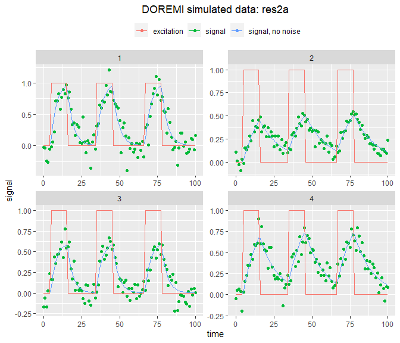

```r
plot(res2a)
```

# Analyzing data

## Example 3 - Analyzing data from a single individual

In this case, we can reuse one of the signals from the previous example

```r
data3 <- data.frame(U2a,
                 signalcol = res2a[id==1]$signal)
```

As the table contains data from a single individual, the `id` parameter has been omitted when calling the function.

```r
#Analyzing
res3 <- analyze.1order(data = data3,
                      input = "exc",
                      time ="t",
                      signal = "signalcol",
                      verbose=T)
```

```
#> INFO [2020-07-10 13:06:06] Input data contains  single individual.
#> INFO [2020-07-10 13:06:06] One or several excitations. Linear regression calculated
#> INFO [2020-07-10 13:06:06] Linear mixed-effect model had no errors.
#> INFO [2020-07-10 13:06:06] One or several excitation terms. Calculation of estimated signal with deSolve
```

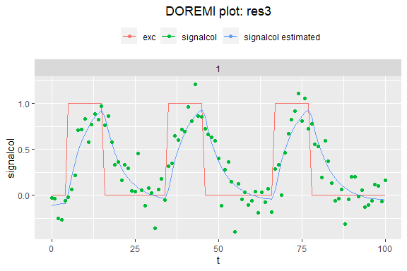

```r
#Plotting
plot(res3)
```

## Example 3a - Analyzing data with several individuals and some inter and intra-individual noise

Analyzing the data generated in the example 2 above (table res2a), the user must specify the name of the columns containing the id of the participants, the excitation, and the signal. As several methods are available for the estimation of the derivatives, the user needs to specify which method to use (`gold` is the default) and the embedding dimension by modifying the parameter “derparam” (see the package pdf manual for more details).

```r
res3a <- analyze.1order(data = res2a,
                        id = "id",
                        input ="excitation",
                        time ="time",
                        signal = "signal",
                        dermethod = "gold",
                        derparam = 5,
                        order = 1)
```

Now let’s take a look at the result. When calling the variable, the mean three coefficients of the differential equation found and the R2 are displayed:

```r
res3a
```

```
#>     id      tau         yeq excitation_k       R2
#> 1: All 6.665909 -0.04121904    0.9631789 0.843298
```

This is a simplified view of the results. The analysis function supplies an object of class “doremi” that contains in fact several lists. It is possible to explore the full result values by using the function “summary” for doremi objects (see the section on methods created for doremi objects at the end of this vignette).

```r
summary(res3a)
```

```
#> Derivative and mean calculation ($data):
#>      id excitation time      signal signal_rollmean signal_derivate1
#>   1:  1          0    0 -0.02321505     -0.12598151      -0.02963659
#>   2:  1          0    1 -0.03783869     -0.12507839       0.02264976
#>   3:  1          0    2 -0.24696250     -0.10507878       0.08626922
#>   4:  1          0    3 -0.26314792     -0.01151139       0.10889475
#>   5:  1          0    4 -0.05874340      0.18385249       0.17844036
#>  ---
#> 400:  4          0   96  0.20262966      0.07502369      -0.02089926
#> 401:  4          0   97  0.07081258              NA               NA
#> 402:  4          0   98 -0.07883158              NA               NA
#> 403:  4          0   99  0.09393630              NA               NA
#> 404:  4          0  100  0.08657149              NA               NA
#>      time_derivate excitation_rollmean totalexc totalexcroll signal_estimated
#>   1:             2                 0.0        0    0.0000000      -0.18104972
#>   2:             3                 0.2        0    0.2169145      -0.15046360
#>   3:             4                 0.4        0    0.4338291      -0.12598151
#>   4:             5                 0.6        0    0.6507436      -0.10638576
#>   5:             6                 0.8        0    0.8676582      -0.09069925
#>  ---
#> 400:            98                 0.0        0    0.0000000       0.12958307
#> 401:            NA                  NA        0           NA       0.11434125
#> 402:            NA                  NA        0           NA       0.10019126
#> 403:            NA                  NA        0           NA       0.08705488
#> 404:            NA                  NA        0           NA       0.07485950
#>
#>  Mixed-effects regression results ($regression):
#> [[1]]
#> Linear mixed model fit by REML. t-tests use Satterthwaite's method [
#> lmerModLmerTest]
#> Formula: paste0("signal_derivate1 ~ signal_rollmean + (1 +", paste(doremiexc,
#>     "rollmean ", collapse = "+", sep = "_"), " + signal_rollmean |id) + ",
#>     paste(doremiexc, "rollmean ", collapse = "+", sep = "_"))
#>    Data: intdata
#> Control: lmerControl(calc.derivs = FALSE, optimizer = "nloptwrap")
#>
#> REML criterion at convergence: -1478.8
#>
#> Scaled residuals:
#>     Min      1Q  Median      3Q     Max
```

[output cut: 35 more lines]

```
#>     id      tau         yeq excitation_k       R2
#> 1: All 6.665909 -0.04121904    0.9631789 0.843298
#>
#>  Coefficients per individual ($resultid):
#>    id       tau         yeq excitation_k
#> 1:  1  4.492673 -0.02778071     1.084573
#> 2:  2 16.078286 -0.09942104     1.081212
#> 3:  3  4.150078 -0.02566226     0.696349
#> 4:  4 13.453773 -0.08319220     1.365898
#>
#>  Derivative estimation method used ($dermethod):
#> [1] "calculate.gold"
#>
#>  Embedding number/smoothing parameter ($derparam):
#> [1] 5
```

The first object of the output contains the original data with some columns added. These columns contain intermediate variables necessary for the mixed-effect regression:

```r
head(res3a$data)
```

```
#>    id excitation time      signal signal_rollmean signal_derivate1
#> 1:  1          0    0 -0.02321505     -0.12598151      -0.02963659
#> 2:  1          0    1 -0.03783869     -0.12507839       0.02264976
#> 3:  1          0    2 -0.24696250     -0.10507878       0.08626922
#> 4:  1          0    3 -0.26314792     -0.01151139       0.10889475
#> 5:  1          0    4 -0.05874340      0.18385249       0.17844036
#> 6:  1          1    5 -0.01869945      0.33863931       0.21192924
#>    time_derivate excitation_rollmean totalexc totalexcroll signal_estimated
#> 1:             2                 0.0 0.000000    0.0000000      -0.18104972
#> 2:             3                 0.2 0.000000    0.2169145      -0.15046360
#> 3:             4                 0.4 0.000000    0.4338291      -0.12598151
#> 4:             5                 0.6 0.000000    0.6507436      -0.10638576
#> 5:             6                 0.8 0.000000    0.8676582      -0.09069925
#> 6:             7                 1.0 1.084573    1.0845727       0.03408149
```

Where:

- signal_rollmean contains the roll mean (moving average) values of the input signal in embedding points (`gold`, `glla`) or in the initial time points provided (`fda`).
- signal_derivate1 contains the first derivate of signal, calculated by using one of the derivative estimation methods available (`gold`, `glla`, `fda`).
- time_derivate contains the values of time in which the derivative has been evaluated.
- excitation_rollmean contains the roll mean of the excitation signal in embedding points (gold, glla) or in the initial time points provided (`fda`).

If we want to visualize the summary of the mixed-effect regression:

```r
res3a$regression
```

```
#> [[1]]
#> Linear mixed model fit by REML. t-tests use Satterthwaite's method [
#> lmerModLmerTest]
#> Formula: paste0("signal_derivate1 ~ signal_rollmean + (1 +", paste(doremiexc,
#>     "rollmean ", collapse = "+", sep = "_"), " + signal_rollmean |id) + ",
#>     paste(doremiexc, "rollmean ", collapse = "+", sep = "_"))
#>    Data: intdata
#> Control: lmerControl(calc.derivs = FALSE, optimizer = "nloptwrap")
#>
#> REML criterion at convergence: -1478.8
#>
#> Scaled residuals:
#>     Min      1Q  Median      3Q     Max
#> -3.4686 -0.5681 -0.0042  0.5862  3.2746
#>
#> Random effects:
#>  Groups   Name            Variance Std.Dev. Corr
#>  id       (Intercept)     0.000000 0.00000
#>           input1_rollmean 0.006025 0.07762    NaN
#>           signal_rollmean 0.009248 0.09617    NaN -0.87
#>  Residual                 0.001149 0.03389
#> Number of obs: 388, groups:  id, 4
#>
#> Fixed effects:
#>                   Estimate Std. Error         df t value Pr(>|t|)
#> (Intercept)      -0.006184   0.002871 380.132701  -2.154   0.0319 *
#> signal_rollmean  -0.150017   0.049072   2.993462  -3.057   0.0553 .
#> input1_rollmean   0.144493   0.039166   2.966439   3.689   0.0352 *
#> ---
#> Signif. codes:  0 '***' 0.001 '**' 0.01 '*' 0.05 '.' 0.1 ' ' 1
#>
#> Correlation of Fixed Effects:
#>             (Intr) sgnl_r
#> signl_rllmn -0.115
#> inpt1_rllmn -0.015 -0.864
#>
#> [[2]]
#> $id
#>   (Intercept) input1_rollmean signal_rollmean
#> 1           0      0.09691596     -0.07256758
#> 2           0     -0.07724651      0.08782137
#> 3           0      0.02329853     -0.09094225
#> 4           0     -0.04296797      0.07568846
#>
#> with conditional variances for "id"
```

Where we have the random and fixed effects and the residuals calculated by the function `lmer` or `lm` depending on if the sample had several or one individual respectively.

Beware that, as known in the two-steps procedures, the estimation of derivatives is a source of vias and thus the error terms provided by the regression are not final. Nevertheless, it is possible to obtain from the summary of the regression the standard errors calculated for the coefficients estimated that will be $\gamma$, $k\gamma$ and $y_{eq}\gamma$.

The following table contains the average of these coefficients for all the individuals (result displayed by default when calling a doremi variable, as mentioned before):

```r
res3a$resultmean
```

```
#>     id      tau         yeq excitation_k       R2
#> 1: All 6.665909 -0.04121904    0.9631789 0.843298
```

```r
res3a$resultid
```

```
#>    id       tau         yeq excitation_k
#> 1:  1  4.492673 -0.02778071     1.084573
#> 2:  2 16.078286 -0.09942104     1.081212
#> 3:  3  4.150078 -0.02566226     0.696349
#> 4:  4 13.453773 -0.08319220     1.365898
```

Where:

- tau is the decay time.
- yeq is the equilibrium value.
- excitation_k is the gain associated to the excitation “excitation”. As we will see later, there is the possibility to consider several excitations, each one of which will have a different effect on the dynamics of the signal studied and thus, a different gain associated to them.

If we graphically wish to verify how the estimated signal fits the initial signal, we can once again call the function `plot`, that has been adapted to handle doremi objects as well:

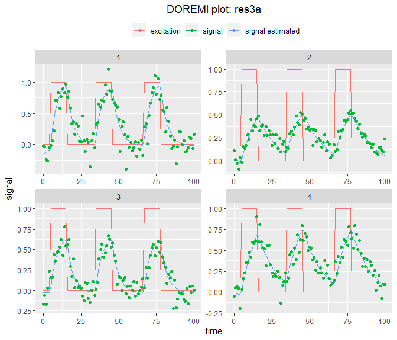

```r
plot(res3a)
```

Similarly to the `print` function, `plot` applied to a doremi object plots by default the first six individuals contained in the result. If we wish to visualize a single individual or a specific set of individuals, we can specify them by changing the “id” input parameter of the function:

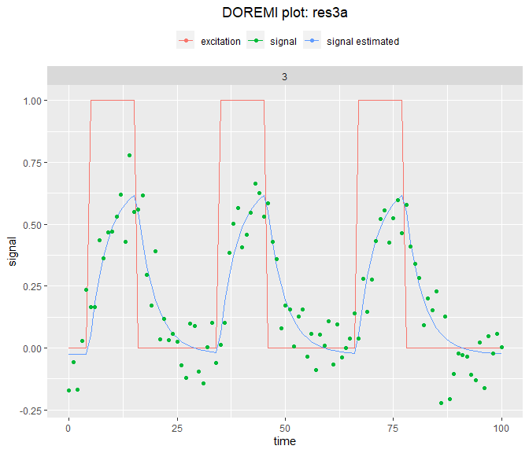

```r
plot(res3a, id = 3)
```

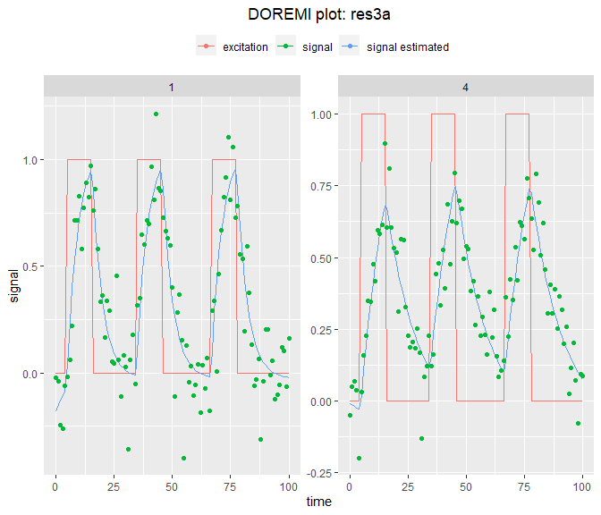

```r
plot(res3a, id = c(1,4))
```

Finally, the result contains the derivative method used and the embedding number/smoothing parameter used for further reference.

## Example 3b - Enhancing the fit by changing the embedding number/ smoothing parameter.

As it was mentioned before, the estimation of derivatives is a source of vias. It is possible to enhance the quality of the fit in three ways:

- By changing the embedding number/smoothing parameter
- By changing the order of the derivative
- By changing the derivation method

In the following example, we will use the function `optimum_param` to find the embedding number that provides the closest R2 to 1. The other ways can be tested “manually” by calling the other functions, for instance, in a simulation study.

```r
time <- 0:100
simu_data <- generate.panel.1order(time = time,
                                   excitation = as.numeric(time>40),
                                   y0 = 0,
                                   t0 = 0,
                                   exc0 = 0,
                                   tau = 10,
                                   k = 1,
                                   yeq = 0,
                                   nind = 10,
                                   internoise = 0.2,
                                   intranoise = 5)
```

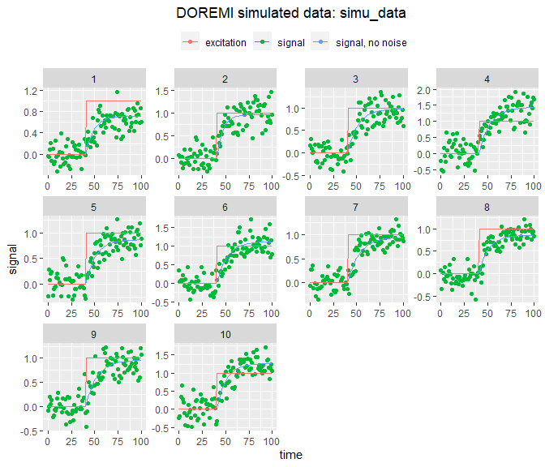

```r
plot(simu_data)
```

```r
res3b<-optimum_param (data = as.data.table(simu_data),
                      id = "id",
                      input = "excitation",
                      time = "time",
                      signal = "signal",
                      model = "1order",
                      dermethod = "glla",
                      pmin = 3,
                      pmax = 11,
                      pstep = 2)
res3b$analysis
```

```
#>     id      tau         yeq excitation_k        R2  D
#> 1: All 33.50836 0.043653832     1.357794 0.6477921  3
#> 2: All 24.80275 0.015099075     1.200293 0.6993794  5
#> 3: All 18.62120 0.009430429     1.115763 0.7785348  7
#> 4: All 16.09292 0.012520819     1.053122 0.7962798  9
#> 5: All 14.99283 0.019034310     1.037566 0.8113729 11
```

```r
res3b$summary_opt
```

```
#>     id      tau        yeq excitation_k        R2  D method
#> 1: All 14.99283 0.01903431     1.037566 0.8113729 11   glla
```

```r
res3b$d
```

```
#> [1] 11
```

THe optimum_param function, generates an object of class “doremiparam”. If we want to graphically see the evolution of the coefficients according to the embedding number, we can easily plot the results with the `plot` function too:

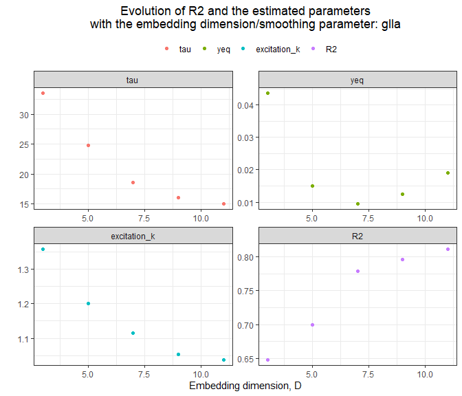

```r
plot(res3b)
```